# Foundations of Data Science Project - Diabetes Analysis

## Context

Diabetes is one of the most frequent diseases worldwide and the number of diabetic patients are growing over the years. The main cause of diabetes remains unknown, yet scientists believe that both genetic factors and environmental lifestyle play a major role in diabetes.

A few years ago research was done on a tribe in America which is called the Pima tribe. In this tribe, it was found that the ladies are prone to diabetes very early. Several constraints were placed on the selection of these instances from a larger database. In particular, all patients were females at least 21 years old of Pima tribe.

## Objective

Here, we are analyzing different aspects of Diabetes in the Pima Diabetes Analysis by doing Exploratory Data Analysis.

## Data Dictionary

The dataset has the following information:

- Pregnancies: Number of times pregnant
- Glucose: Plasma glucose concentration over 2 hours in an oral glucose tolerance test
- BloodPressure: Diastolic blood pressure (mm Hg)
- SkinThickness: Triceps skin fold thickness (mm)
- Insulin: 2-Hour serum insulin (mu U/ml)
- BMI: Body mass index (weight in kg/(height in m)^2)
- DiabetesPedigreeFunction: A function that scores the likelihood of diabetes based on family history.
- Age: Age in years
- Outcome: Class variable (0: a person is not diabetic or 1: a person is diabetic)

## Q 1: Import the necessary libraries and briefly explain the use of each library (3 Marks)

```python
import numpy as np
import pandas as pd

import seaborn as sns
import matplotlib.pyplot as plt
%matplotlib inline
```

### Ans 1:

#### Numpy

Short for Numerical Python, numpy is a library containing many functions useful in scientific computing and notably the datatype ndarray (n-dimensional array).

#### Pandas

Pandas derives its name from Panel Data and is another package useful in scientific computing. It is dependant on numpy and the main datatypes Pandas brings are the DataFrame and Series.

#### Matplotlib.pyplot

Matplotlib is a package for data visualization which is very flexible. Pyplot is a collection of functions within Matplotlib and is usually sufficient to import rather than the full Matplotlib library.

#### Seaborn

Seaborn is a plotting package which depends on Matplotlib and adds plot types to the baseline collection. The mantra around matplotlib and seaborn is "Matplotlib makes easy thing easy and hard things possible. Seaborn makes a selection of hard things easy."

## Q 2: Read the given dataset (1 Mark)

```python
pima = pd.read_csv("diabetes.csv")
```

## Q3. Show the last 10 records of the dataset. How many columns are there? (1 Mark)

```python
pima.tail(10)
```

|  | Pregnancies | Glucose | BloodPressure | SkinThickness | Insulin | BMI | DiabetesPedigreeFunction | Age | Outcome |
| --- | --- | --- | --- | --- | --- | --- | --- | --- | --- |
| 758 | 1 | 106 | 76 | 20 | 79 | 37.5 | 0.197 | 26 | 0 |
| 759 | 6 | 190 | 92 | 20 | 79 | 35.5 | 0.278 | 66 | 1 |
| 760 | 2 | 88 | 58 | 26 | 16 | 28.4 | 0.766 | 22 | 0 |
| 761 | 9 | 170 | 74 | 31 | 79 | 44.0 | 0.403 | 43 | 1 |
| 762 | 9 | 89 | 62 | 20 | 79 | 22.5 | 0.142 | 33 | 0 |
| 763 | 10 | 101 | 76 | 48 | 180 | 32.9 | 0.171 | 63 | 0 |
| 764 | 2 | 122 | 70 | 27 | 79 | 36.8 | 0.340 | 27 | 0 |
| 765 | 5 | 121 | 72 | 23 | 112 | 26.2 | 0.245 | 30 | 0 |
| 766 | 1 | 126 | 60 | 20 | 79 | 30.1 | 0.349 | 47 | 1 |
| 767 | 1 | 93 | 70 | 31 | 79 | 30.4 | 0.315 | 23 | 0 |

### Ans 3:

The index is not counted as a column, so there are 9 columns in this DataFrame.

## Q4. Show the first 10 records of the dataset (1 Mark)

```python
pima.head(10)
```

|  | Pregnancies | Glucose | BloodPressure | SkinThickness | Insulin | BMI | DiabetesPedigreeFunction | Age | Outcome |
| --- | --- | --- | --- | --- | --- | --- | --- | --- | --- |
| 0 | 6 | 148 | 72 | 35 | 79 | 33.600000 | 0.627 | 50 | 1 |
| 1 | 1 | 85 | 66 | 29 | 79 | 26.600000 | 0.351 | 31 | 0 |
| 2 | 8 | 183 | 64 | 20 | 79 | 23.300000 | 0.672 | 32 | 1 |
| 3 | 1 | 89 | 66 | 23 | 94 | 28.100000 | 0.167 | 21 | 0 |
| 4 | 0 | 137 | 40 | 35 | 168 | 43.100000 | 2.288 | 33 | 1 |
| 5 | 5 | 116 | 74 | 20 | 79 | 25.600000 | 0.201 | 30 | 0 |
| 6 | 3 | 78 | 50 | 32 | 88 | 31.000000 | 0.248 | 26 | 1 |
| 7 | 10 | 115 | 69 | 20 | 79 | 35.300000 | 0.134 | 29 | 0 |
| 8 | 2 | 197 | 70 | 45 | 543 | 30.500000 | 0.158 | 53 | 1 |
| 9 | 8 | 125 | 96 | 20 | 79 | 31.992578 | 0.232 | 54 | 1 |

## Q5. What do you understand by the dimension of the dataset? Find the dimension of the `pima` dataframe. (1 Mark)

```python
pima.shape
```

```
(768, 9)
```

### Ans 5:

The Pima DataFrame is a 2-dimensional data structure with 768 rows and 9 columns of data.

## Q6. What do you understand by the size of the dataset? Find the size of the `pima` dataframe. (1 Mark)

```python
pima.size
```

```
6912
```

```python
nr, nc = pima.shape
print(nr*nc)
```

```
6912
```

### Ans 6:

The Pima dataset contains (n_rows)x(n_columns)=(768)x(9)=6912 entries.

## Q7. What are the data types of all the variables in the data set? (2 Marks)

**Hint: Use the info() function to get all the information about the dataset.**

```python
pima.info()
```

```
<class 'pandas.core.frame.DataFrame'>
RangeIndex: 768 entries, 0 to 767
Data columns (total 9 columns):
 #   Column                    Non-Null Count  Dtype
---  ------                    --------------  -----
 0   Pregnancies               768 non-null    int64
 1   Glucose                   768 non-null    int64
 2   BloodPressure             768 non-null    int64
 3   SkinThickness             768 non-null    int64
 4   Insulin                   768 non-null    int64
 5   BMI                       768 non-null    float64
 6   DiabetesPedigreeFunction  768 non-null    float64
 7   Age                       768 non-null    int64
 8   Outcome                   768 non-null    int64
dtypes: float64(2), int64(7)
memory usage: 54.1 KB
```

### Ans 7:

The Pima dataset contains two types of data: integers and floats. There are 7 integer (int64) variables: Pregnancies, Glucose, BloodPressure, SkinThickness, Insulin, Age, and Outcome. There are 2 floating point decimal (float64) variables: BMI, and DiabetesPedigreeFunction. Outcome is stored as an integer, but is effectively being used as a bool in this dataset.

## Q8. What do we mean by missing values? Are there any missing values in the `pima` dataframe? (2 Marks)

```python
pima.isnull().values.any()
```

```
False
```

### Ans 8:

Missing values are gaps or holes in our data set. There are no missing values in the Pima DataFrame. This could also have been seen from `pima.info()` where every row indicates all 768 values are non-null.

## Q9. What do the summary statistics of the data represent? Find the summary statistics for all variables except 'Outcome' in the `pima` data. Take one column/variable from the output table and explain all its statistical measures. (3 Marks)

```python
pima.iloc[:,0:8].describe()
```

|  | Pregnancies | Glucose | BloodPressure | SkinThickness | Insulin | BMI | DiabetesPedigreeFunction | Age |
| --- | --- | --- | --- | --- | --- | --- | --- | --- |
| count | 768.000000 | 768.000000 | 768.000000 | 768.000000 | 768.000000 | 768.000000 | 768.000000 | 768.000000 |
| mean | 3.845052 | 121.675781 | 72.250000 | 26.447917 | 118.270833 | 32.450805 | 0.471876 | 33.240885 |
| std | 3.369578 | 30.436252 | 12.117203 | 9.733872 | 93.243829 | 6.875374 | 0.331329 | 11.760232 |
| min | 0.000000 | 44.000000 | 24.000000 | 7.000000 | 14.000000 | 18.200000 | 0.078000 | 21.000000 |
| 25% | 1.000000 | 99.750000 | 64.000000 | 20.000000 | 79.000000 | 27.500000 | 0.243750 | 24.000000 |
| 50% | 3.000000 | 117.000000 | 72.000000 | 23.000000 | 79.000000 | 32.000000 | 0.372500 | 29.000000 |
| 75% | 6.000000 | 140.250000 | 80.000000 | 32.000000 | 127.250000 | 36.600000 | 0.626250 | 41.000000 |
| max | 17.000000 | 199.000000 | 122.000000 | 99.000000 | 846.000000 | 67.100000 | 2.420000 | 81.000000 |

### Ans 9:

**count:** The total number of entries in that column. Ex. There are 768 data points regarding the glucose level in the patients.

**mean:** The average value in that column type, calculated as $\frac{1}{n}\sum_{i=1}^{n}x_i$ where n=768 is the number of entries and $x_i$ is the value of entry $i$. Ex. If we added up the total glucose level for all patients and divide by the number of patients in this dataset, we find an average glucose level of approximately 121.68.

**std = Standard Deviation, $\sigma$:** A statistic describing how dispersed the dataset is. If we take $\mu$ as the calculated mean and use the variables as described above, then $\sigma=\sqrt{\frac{\sum_{i=0}^n ( x_i - \mu )^2}{n}}$. In a Gaussian distribution, approximately 68% of the data fall within the range $\mu-\sigma$ to $\mu+\sigma$. Ex. With regard to glucose level in this dataset, $\sigma\approx30.44$.

**min = minimum value:** This is the smallest value in the dataset for the given variable. Ex. There is at least one patient who had a glucose level of 44 and no patients with a glucose level less than 44.

**25% = First Quartile:** This is the threshold at which 25% of the data have smaller values. Ex. 25% of the patients (192) have a glucose level below 99.75.

**50% = Second Quartile = Median:** This is the threshold at which half of the data have smaller values and half of the data have larger values. Ex. 50% of the patients (384) have a glucose level less than 117.00.

**75% = Third Quartile:** This is the threshold at which three quarters of the data have smaller values. Ex. 75% of the patients (576) have glucose levels below 140.25.

**max = maximum value:** This is the largest value in the dataset for the gien variable. Ex. There is at least one patient who had a glucose level of 199 and there are no patients who had a glucose level higher than 199.

## Q 10. Plot the distribution plot for the variable 'BloodPressure'. Write detailed observations from the plot. (2 Marks)

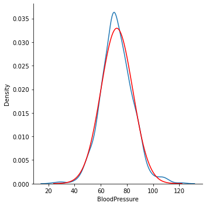

```
72.25
12.117202529118751
```

```python
sns.displot(pima['BloodPressure'], kind='kde')

import scipy.stats as stats
varname='BloodPressure'
BPmin  = pima[varname].min()
BPmax  = pima[varname].max()
BPmean = pima[varname].mean()
BPstd  = pima[varname].std()
x = np.linspace(BPmin,BPmax,300)
plt.plot(x, stats.norm.pdf(x, BPmean, BPstd),color='red')
plt.show()

print(BPmean)
print(BPstd)
```

### Ans 10:

In the Pima dataset, the BloodPressure variable roughly traces a Gaussian distribution, centered around 72 and with a standard deviation of 12, though the data are more sharply peaked and skewed to lower values. On the high side there is a small secondary peak, or shoulder, of patients with a blood pressure between 100 and 115.

## Q 11. What is the 'BMI' of the person having the highest 'Glucose'? (1 Mark)

```python
pima[pima['Glucose']==pima['Glucose'].max()]['BMI']
```

```
661    42.9
Name: BMI, dtype: float64
```

### Ans 11:

The person who has the maximum measure of glucose has a BMI of 42.9. This falls within the upper quartile of the BMI distribution.

## Q12.

### 12.1 What is the mean of the variable 'BMI'?

### 12.2 What is the median of the variable 'BMI'?

### 12.3 What is the mode of the variable 'BMI'?

### 12.4 Are the three measures of central tendency equal?

### (3 Marks)

```python
m1 = pima['BMI'].mean()  # mean
print(m1)
m2 = pima['BMI'].median()  # median
print(m2)
m3 = pima['BMI'].mode()[0]  # mode
print(m3)
```

```
32.45080515543619
32.0
32.0
```

### Ans 12:

**a** The mean BMI is 32.45

**b** The median BMI is 32.0

**c** The mode BMI is 32.0

**d** The three measures of central tendency, mean, median, and mode are not necessarily equal though in this case are all very close numerically. The mean is slightly higher than the other two, and the median and mode are equal in this case.

## Q13. How many women's 'Glucose' levels are above the mean level of 'Glucose'? (1 Mark)

```python
pima[pima['Glucose']>pima['Glucose'].mean()].shape[0]
```

```
343
```

### Ans 13:

The above code calculates there being 343 rows in the dataset where the glucose level is greater than the mean glucose level. Each row corresponds to a patient, so there are 343 patients with glucose levels above the mean.

## Q14. How many women have their 'BloodPressure' equal to the median of 'BloodPressure' and their 'BMI' less than the median of 'BMI'? (2 Marks)

```python
pima[(pima['BloodPressure']==pima['BloodPressure'].median()) & (pima['BMI']<pima['BMI'].median())].shape[0]
```

```
22
```

```python
pima[(pima['BloodPressure']==pima['BloodPressure'].median()) ].shape[0]
```

```
44
```

### Ans 14:

There are 44 women who have a blood pressure equal to the median blood pressure, and of that group, half (22) also have a BMI less than the median BMI.

## Q15. Create a pairplot for the variables 'Glucose', 'SkinThickness', and 'DiabetesPedigreeFunction'. Write your observations from the plot. (4 Marks)

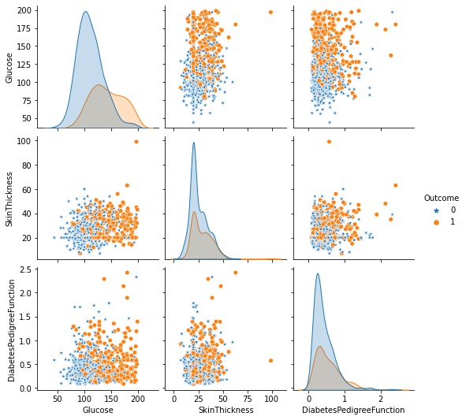

```python
sns.pairplot(data=pima,vars=['Glucose', 'SkinThickness', 'DiabetesPedigreeFunction'], markers=['*','h'], hue='Outcome')
plt.show()
```

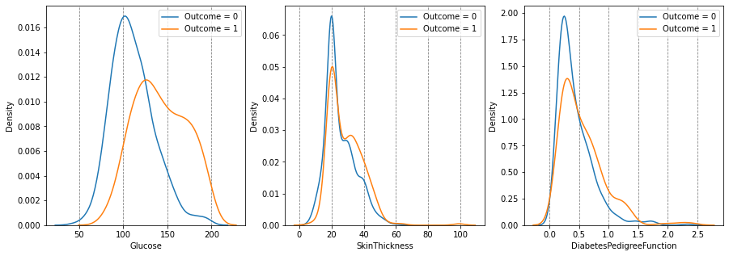

```python
data0 = pima[pima['Outcome']==0]
data1 = pima[pima['Outcome']!=0]
fig, (ax1, ax2, ax3) = plt.subplots(1, 3, figsize=(15,5))
ax1.xaxis.grid(color='gray', linestyle='dashed')
ax2.xaxis.grid(color='gray', linestyle='dashed')
ax3.xaxis.grid(color='gray', linestyle='dashed')

sns.kdeplot(data0['Glucose'], ax=ax1, label="Outcome = 0")
sns.kdeplot(data1['Glucose'], ax=ax1, label="Outcome = 1")
ax1.legend()

sns.kdeplot(data0['SkinThickness'], ax=ax2, label="Outcome = 0")
sns.kdeplot(data1['SkinThickness'], ax=ax2, label="Outcome = 1")
ax2.legend()

sns.kdeplot(data0['DiabetesPedigreeFunction'], ax=ax3, label="Outcome = 0")
sns.kdeplot(data1['DiabetesPedigreeFunction'], ax=ax3, label="Outcome = 1")
ax3.legend()
```

### Ans 15:

#### Single Variable Plots:

**Skin Thickness:** The distribution of skin thickness for patients with positive and negative outcomes are similar in shape, and both appear to be made from multiple underlying Gaussians. For both positive and negative patients, the main peak is around a skin thickness of 20, and in both cases the drop off on the high side is interrupted by a secondary distribution.

**Diabetes Pedigree Function (DPF):** For both positive and negative patients, the DPF is peaked around 0.25, though the positive distribution is shifted slightly to larger values. There is a steep dropoff to the small side for both the positive and negative distributions, and on the high side both distributions fall slower than would be expected for a Gaussian. Proportionally more mositive patients stay with higher values of DPF than do negative patients.

#### Scatter Plots:

**Glucose v Skin Thickness:** The histograms for skin thickness in positive and negative patients are very similar, and adding glucose to make a scatter plot does little to obviously differentiate the two patient types. As would be expected from the glucose histogram, patients with higher glucose levels are more likely to be positive and patients with lower glucose levels are more likely to be negative, but there is no clear relationship between glucose level and skin thickness. There is one very notable outlier which has a high glucose level and high skin thickness and this person tested as positive.

**Glucose v DPF:** The trend of higher glucose values corresponding to higher probabilities of positivity is also visible in this scatter distribution, but there is again little obvious correlation between glucose level and DPF for positive or negative patients. There are a handful of positive outliers with relatively high glucose levals and high DPF but there is also a negative outlier with high glucose and high DPF.

**Skin Thickness v DPF:** Skin thickness and DPF both have very similar positive patient and negative patient shapes in their individual histograms, so it is unsurprising that making a scatter plot of the two variables has substantial overlap between positive and negative patients. While most of the outliers are positive patients with relatively thick skin and a very high DPF, it is also notable that the patient with the thickest skin was also positive and yet had a DPF close to the mean.

## Q16. Plot the scatterplot between 'Glucose' and 'Insulin'. Write your observations from the plot. (2 Marks)

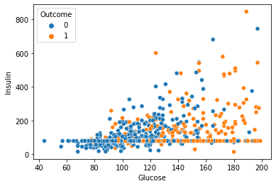

```python
sns.scatterplot(x='Glucose',y='Insulin',data=pima, hue='Outcome')
plt.show()
```

```python
themode = pima['Insulin'].mode()
print(themode[0])
```

```
79
```

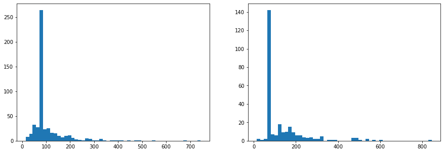

```python
fig, (ax1,ax2) = plt.subplots(1, 2, figsize=(15,5))
ax1.hist(data0['Insulin'],bins=50)
ax2.hist(data1['Insulin'],bins=50)
```

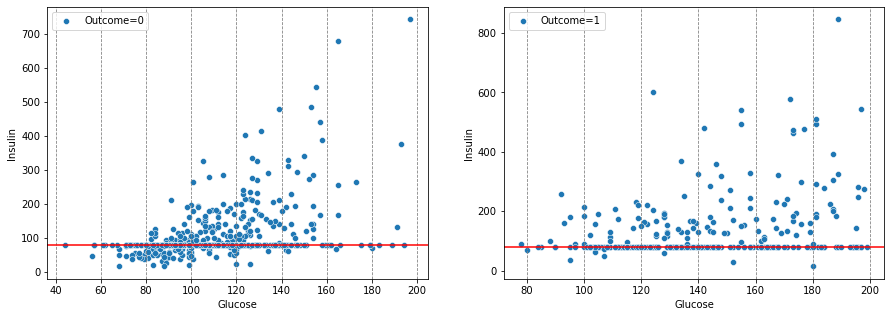

```python
fig, (ax1, ax2) = plt.subplots(1, 2, figsize=(15,5))
ax1.xaxis.grid(color='gray', linestyle='dashed')
ax2.xaxis.grid(color='gray', linestyle='dashed')
ax1.axhline(data0['Insulin'].mode()[0],color='r')
ax2.axhline(data0['Insulin'].mode()[0],color='r')
sns.scatterplot(x='Glucose',y='Insulin',data=data0, ax=ax1, label="Outcome=0")
sns.scatterplot(x='Glucose',y='Insulin',data=data1, ax=ax2, label="Outcome=1")
```

### Ans 16:

One obvious feature that stands out in both the positive and negative outcome distributions is that there is a disproportionately high number of patients with an insulin level of exactly 79 when compared to any other insulin level, even neighboring values. This is true across glucose levels and may indicate that 79 is some sort of a default value assigned when the data was taken. It is most visible in the histograms plotted above the scatter plots.

Comparing insulin levels to glucose levels, there appears to be a weak correlation between the two variables in negative patients, with higher glucose levels corresponding to higher insulin levels. In patients who tested positive, glucose levels show minimal correlation to insulin levels, and patients with high glucose are about as likely to have high insulin as they are low.

It is visible in these plots, though more apparent in the KDE distributions above, that negative patients tend to have lower glucose levels (clustered in the 80-140 range) than patients who tested positive (distributed roughly evenly in the 100-180 range).

## Q 17. Plot the boxplot for the 'Age' variable. Are there outliers? (2 Marks)

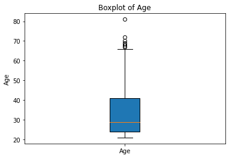

```python
plt.boxplot(x=pima['Age'],labels=['Age'], patch_artist=True  )
plt.title('Boxplot of Age')
plt.ylabel('Age')
plt.show()
```

## Q18. Plot histograms for the 'Age' variable to understand the number of women in different age groups given whether they have diabetes or not. Explain both histograms and compare them. (3 Marks)

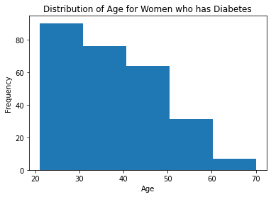

```python
plt.hist(pima[pima['Outcome']==1]['Age'], bins = 5)
plt.title('Distribution of Age for Women who has Diabetes')
plt.xlabel('Age')
plt.ylabel('Frequency')
plt.show()
```

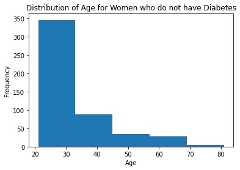

```python
plt.hist(pima[pima['Outcome']==0]['Age'], bins = 5)
plt.title('Distribution of Age for Women who do not have Diabetes')
plt.xlabel('Age')
plt.ylabel('Frequency')
plt.show()
```

```python
#nbins = 5
nbins=[20,25,30,35,40,45,50,55,60,65,70,75,80]
var = 'Age'
```

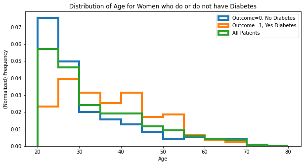

```python
fig, (ax1) = plt.subplots(1, 1, figsize=(10,5))
ax1.hist(data0[var],bins=nbins,histtype='step',
         density=True, label='Outcome=0, No Diabetes', linewidth=4)
ax1.hist(data1[var],bins=nbins,histtype='step',
         density=True, label='Outcome=1, Yes Diabetes', linewidth=4)
ax1.hist(pima[var], bins=nbins,histtype='step',
        density=True, label='All Patients', linewidth=4)
ax1.legend()
plt.title('Distribution of Age for Women who do or do not have Diabetes')
plt.xlabel('Age')
plt.ylabel('(Normalized) Frequency')
plt.show()
```

### Ans 18:

**All Patients** Most of the people surveyed were young, regardless of their positive/negative status, and the age of the participants fell off roughly linearly after age 30.

**No Diabetes** In this study, the majority of patients who did not have diabetes were young (age 20-30). Disproportionately more of the patients who were young did not have diabetes compared with those who did.

**Has Diabetes** Patients who had diabetes were roughly uniformly distributed among the age ranges 20-55. Above 55, the diabetes rate tracked with distribution of ages for all participants.

## Q 19. What is the Interquartile Range of all the variables? Why is this used? Which plot visualizes the same? (2 Marks)

```python
Q1 = pima.quantile(0.25)
Q3 = pima.quantile(0.75)
IQR = Q3 - Q1
print(IQR)
```

```
Pregnancies                  5.0000
Glucose                     40.5000
BloodPressure               16.0000
SkinThickness               12.0000
Insulin                     48.2500
BMI                          9.1000
DiabetesPedigreeFunction     0.3825
Age                         17.0000
Outcome                      1.0000
dtype: float64
```

### Ans 19:

The Interquartile Range (IQR) is defined as the range of the data containing half of the data points, centered around the median value. Numerically, this corresponds to finding the range between the first and third quartiles of the data.

This may be a useful number when trying to understand the spread in the data of a distribution and may be used as an alternative to the standard deviation.

The IQR is the boxed part of a box plot.

## Q 20. Find and visualize the correlation matrix. Write your observations from the plot. (3 Marks)

```python
corr_matrix = pima.iloc[:,0:8].corr()

cm0 = data0.iloc[:,0:8].corr()
cm1 = data1.iloc[:,0:8].corr()

corr_matrix
```

|  | Pregnancies | Glucose | BloodPressure | SkinThickness | Insulin | BMI | DiabetesPedigreeFunction | Age |
| --- | --- | --- | --- | --- | --- | --- | --- | --- |
| Pregnancies | 1.000000 | 0.128022 | 0.208987 | 0.009393 | -0.018780 | 0.021546 | -0.033523 | 0.544341 |
| Glucose | 0.128022 | 1.000000 | 0.219765 | 0.158060 | 0.396137 | 0.231464 | 0.137158 | 0.266673 |
| BloodPressure | 0.208987 | 0.219765 | 1.000000 | 0.130403 | 0.010492 | 0.281222 | 0.000471 | 0.326791 |
| SkinThickness | 0.009393 | 0.158060 | 0.130403 | 1.000000 | 0.245410 | 0.532552 | 0.157196 | 0.020582 |
| Insulin | -0.018780 | 0.396137 | 0.010492 | 0.245410 | 1.000000 | 0.189919 | 0.158243 | 0.037676 |
| BMI | 0.021546 | 0.231464 | 0.281222 | 0.532552 | 0.189919 | 1.000000 | 0.153508 | 0.025748 |
| DiabetesPedigreeFunction | -0.033523 | 0.137158 | 0.000471 | 0.157196 | 0.158243 | 0.153508 | 1.000000 | 0.033561 |
| Age | 0.544341 | 0.266673 | 0.326791 | 0.020582 | 0.037676 | 0.025748 | 0.033561 | 1.000000 |

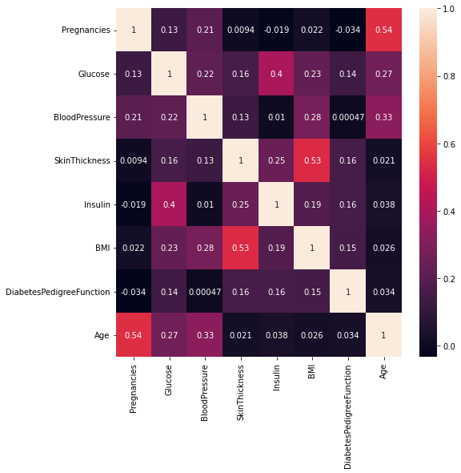

```python
plt.figure(figsize=(8,8))
sns.heatmap(corr_matrix, annot = True)

# display the plot
plt.show()
```

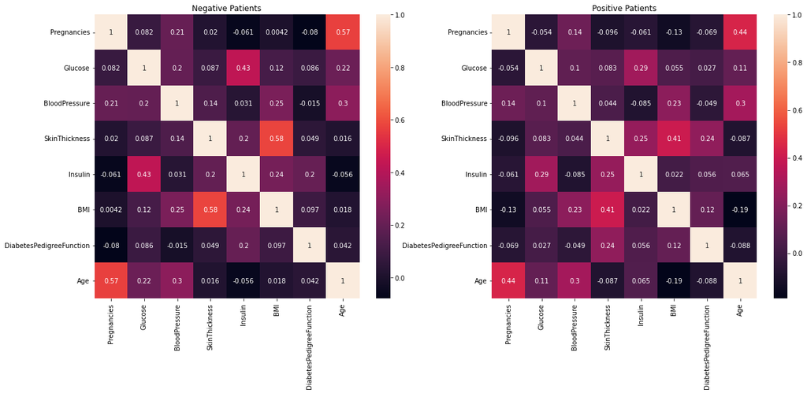

```python
fig, (ax1, ax2) = plt.subplots(1, 2, figsize=(20,8))
sns.heatmap(cm0, annot = True, ax=ax1)
ax1.set_title("Negative Patients")
sns.heatmap(cm1, annot = True, ax=ax2)
ax2.set_title("Positive Patients")
```

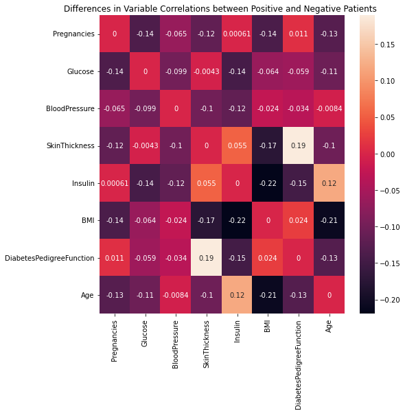

```python
diffmap = cm1-cm0
plt.figure(figsize=(8,8))
sns.heatmap(diffmap, annot = True)
plt.title("Differences in Variable Correlations between Positive and Negative Patients ")
plt.show()
```

### Ans 20:

As can be seen in the correlation matrix plots above, none of the variables in this dataset are very strongly correlated, where strong correlation is defined as having a correlation coefficient $r>0.7$ Of the most correlated variables, the pair (Age / Number of Pregnancies) has a correlation of 0.54 overall and seems intuitive that the older the patient is, the more likely they are to have had a larger number of children. When we compare these correlations between positive and negative patients, the general trend is true for both classes, but the correlation is stronger in negative patients. This indicates that negative patients are more likely to have more children with time than their positive counterparts.

Other leading pairs are (BMI / Skin Thickness), which indicate people with a higher BMI also tend to have thicker skin. Separating the dataset into positive and negative patients, we can see that the trend is less strong among those who are positive, meaning patients who are positive tend to have a smaller amount of skin thickening as their BMI increases than those who are negative.

Continuing with the BMI, when we look at how it tracks with insulin levels, the results are interesting. There is a (weak) correlation between BMI and insulin levels (0.24) for negative patients, but for positive patients, the correlation nearly disappears (0.02).

Another large difference between the populations can be seen by comparing the correlations between skin thickness and the Diabetes Pedigree Function. For negative patients, there is essentially no correlation (0.05) but for positive patients, there is a small positive correlation (0.24).